# Исследование сетевых параметров публичных DNS серверов

## Цель работы

Проанализировать сетевые параметры публичных DNS серверов, сделать мотивированный вывод о предпочтительных серверах

## Используемое ПО

1. Rstudio IDE
2. tracert/tracerout
3. 2ip

## Варианты решения задачи

1. Tracert
2. Tracerout

В данной работе буду использовать вариант для Windows - tracert

## Общий план выполнения

1. Построить маршрут
2. Определить местоположение каждого узла маршрута к DNS-серверу, организацию, владеющую каждым узлом маршрута к DNS-серверу
3. Расчитать среднее RTT к DNS-серверу
4. Выделить те узлы маршрута, которые вносят наибольшую временную задержку при передаче

## Исследуемые провайдеры DNS

1. Google Public DNS
2. Cloudflare DNS
3. OpenDNS
4. DNS вашего провайдера

## Ход работы

Google Public DNS

1. Строим маршрут

```r
system("tracert 8.8.8.8", intern = TRUE)
```

```
##  [1] ""
##  [2] "’а ббЁа®ўЄ  ¬ аиагв  Є dns.google [8.8.8.8]"
##  [3] "б ¬ ЄбЁ¬ «мл¬ зЁб«®¬ Їал¦Є®ў 30:"
##  [4] ""
##  [5] "  1     3 ms     1 ms    <1 ¬б  router.asus.com [192.168.1.1] "
##  [6] "  2     *        4 ms     1 ms  172.18.0.1 "
##  [7] "  3     2 ms     2 ms     6 ms  gw-core.gptel.ru [77.73.25.1] "
##  [8] "  4    12 ms    44 ms     9 ms  gptel145.cln.net [79.98.8.145] "
##  [9] "  5     3 ms     3 ms     8 ms  cln-google-gw.cln.net [79.98.8.194] "
## [10] "  6     6 ms     5 ms     4 ms  108.170.250.146 "
## [11] "  7    17 ms    18 ms    20 ms  216.239.50.2 "
## [12] "  8    18 ms    22 ms     *     216.239.48.224 "
## [13] "  9    21 ms    22 ms    20 ms  172.253.51.219 "
## [14] " 10     *        *        *     ЏаҐўлиҐ ЁвҐаў « ®¦Ё¤ Ёп ¤«п § Їа®б ."
## [15] " 11     *        *        *     ЏаҐўлиҐ ЁвҐаў « ®¦Ё¤ Ёп ¤«п § Їа®б ."
## [16] " 12     *        *        *     ЏаҐўлиҐ ЁвҐаў « ®¦Ё¤ Ёп ¤«п § Їа®б ."
## [17] " 13     *        *        *     ЏаҐўлиҐ ЁвҐаў « ®¦Ё¤ Ёп ¤«п § Їа®б ."
## [18] " 14     *        *        *     ЏаҐўлиҐ ЁвҐаў « ®¦Ё¤ Ёп ¤«п § Їа®б ."
## [19] " 15     *        *        *     ЏаҐўлиҐ ЁвҐаў « ®¦Ё¤ Ёп ¤«п § Їа®б ."
## [20] " 16     *        *        *     ЏаҐўлиҐ ЁвҐаў « ®¦Ё¤ Ёп ¤«п § Їа®б ."
## [21] " 17     *        *        *     ЏаҐўлиҐ ЁвҐаў « ®¦Ё¤ Ёп ¤«п § Їа®б ."
## [22] " 18     *        *        *     ЏаҐўлиҐ ЁвҐаў « ®¦Ё¤ Ёп ¤«п § Їа®б ."
## [23] " 19    18 ms    17 ms    21 ms  dns.google [8.8.8.8] "
## [24] ""
## [25] "’а ббЁа®ўЄ  § ўҐаиҐ ."
```

2. Собираем информацию

[output not shown]

Cloudflare DNS

1. Строим маршрут

```r
system("tracert 1.1.1.1", intern = TRUE)
```

```
##  [1] ""
##  [2] "’а ббЁа®ўЄ  ¬ аиагв  Є one.one.one.one [1.1.1.1]"
##  [3] "б ¬ ЄбЁ¬ «мл¬ зЁб«®¬ Їал¦Є®ў 30:"
##  [4] ""
##  [5] "  1    <1 ¬б     1 ms     1 ms  router.asus.com [192.168.1.1] "
##  [6] "  2     4 ms     1 ms    <1 ¬б  172.18.0.1 "
##  [7] "  3     7 ms     1 ms     5 ms  gw-core.gptel.ru [77.73.25.1] "
##  [8] "  4    17 ms     5 ms     3 ms  77.94.162.77 "
##  [9] "  5     9 ms    11 ms    14 ms  msk-ix.cloudflare.com [195.208.209.7] "
## [10] "  6     2 ms     6 ms     8 ms  one.one.one.one [1.1.1.1] "
## [11] ""
## [12] "’а ббЁа®ўЄ  § ўҐаиҐ ."
```

2. Собираем информацию

| № | Время | Время | Время | Узел | Местоположение узла | Организация | Средняя RTT к DNS | Вносит наибольшую временную задержку при передаче |
| --- | --- | --- | --- | --- | --- | --- | --- | --- |
| 1 | <1 ms | 1 ms | 1 ms | 192.168.1.1 | Москва | Router | 0,8 | 1 |
| 2 | 4 ms | 1 ms | <1 ms | 172.18.0.1 | Москва | Гран При Телеком | 1,8 | 2 |
| 3 | 7 ms | 1 ms | 5 ms | 77.73.25.1 | Москва | Гран При Телеком | 4,3 | 3 |
| 4 | 17 ms | 5 ms | 3 ms | 77.94.162.77 | Москва | CLN | 8,3 | 5 |
| 5 | 9 ms | 11 ms | 14 ms | 195.208.209.7 | Москва | CLN | 11,3 | 6 |
| 6 | 2 ms | 6 ms | 8 ms | 1.1.1.1 | Research, Australia | Cloudflare DNS | 5,3 | 4 |

OpenDNS

1. Строим маршрут

```r
system("tracert 208.67.220.220", intern = TRUE)
```

```
##  [1] ""
##  [2] "’а ббЁа®ўЄ  ¬ аиагв  Є resolver2.opendns.com [208.67.220.220]"
##  [3] "б ¬ ЄбЁ¬ «мл¬ зЁб«®¬ Їал¦Є®ў 30:"
##  [4] ""
##  [5] "  1     1 ms    <1 ¬б     1 ms  router.asus.com [192.168.1.1] "
##  [6] "  2     *        1 ms     3 ms  172.18.0.1 "
##  [7] "  3     1 ms     2 ms     1 ms  gw-core.gptel.ru [77.73.25.1] "
##  [8] "  4    12 ms     2 ms     3 ms  77.94.162.77 "
##  [9] "  5     *        *        *     ЏаҐўлиҐ ЁвҐаў « ®¦Ё¤ Ёп ¤«п § Їа®б ."
## [10] "  6     *        *        *     ЏаҐўлиҐ ЁвҐаў « ®¦Ё¤ Ёп ¤«п § Їа®б ."
## [11] "  7     *        *        *     ЏаҐўлиҐ ЁвҐаў « ®¦Ё¤ Ёп ¤«п § Їа®б ."
## [12] "  8    38 ms    43 ms    35 ms  resolver2.opendns.com [208.67.220.220] "
## [13] ""
## [14] "’а ббЁа®ўЄ  § ўҐаиҐ ."
```

2. Собирам информацию

[output not shown]

ООО “Гран При Телеком”

1. Строим маршрут

```r
system("tracert 77.73.24.2", intern = TRUE)
```

```
##  [1] ""
##  [2] "’а ббЁа®ўЄ  ¬ аиагв  Є ns.gptel.ru [77.73.24.2]"
##  [3] "б ¬ ЄбЁ¬ «мл¬ зЁб«®¬ Їал¦Є®ў 30:"
##  [4] ""
##  [5] "  1    21 ms     7 ms    10 ms  router.asus.com [192.168.1.1] "
##  [6] "  2     1 ms     2 ms     1 ms  172.18.0.1 "
##  [7] "  3     *        1 ms     3 ms  gw-aggr1.gptel.ru [77.73.25.6] "
##  [8] "  4     3 ms     2 ms     2 ms  ns.gptel.ru [77.73.24.2] "
##  [9] ""
## [10] "’а ббЁа®ўЄ  § ўҐаиҐ ."
```

2. Собираем информацию

| № | Время | Время | Время | Узел | Местоположение узла | Организация | Средняя RTT к DNS | Вносит наибольшую временную задержку при передаче |
| --- | --- | --- | --- | --- | --- | --- | --- | --- |
| 1 | 21 ms | 7 ms | 10 ms | 192.168.1.1 | Москва | Router | 12,6 | 4 |
| 2 | 1 ms | 2 ms | 1 ms | 172.18.0.1 | Москва | Гран При Телеком | 1,3 | 2 |
| 3 | * | 1 ms | 3 ms | 77.73.25.6 | Москва | Гран При Телеком | 1,3 | 2 |
| 4 | 3 ms | 2 ms | 2 ms | 77.73.24.2 | Москва | network for GRANDPRIX Telecom | 2,3 | 3 |

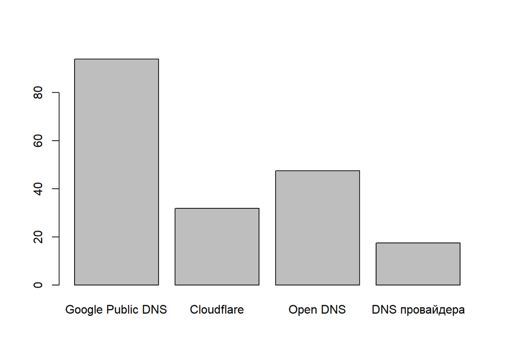

```r
time <- c(93.9, 31.8, 47.4, 17.5)
name <- c("Google Public DNS", "Cloudflare",  "Open DNS", "DNS провайдера")
DNS <- data.frame(Name= name, Time = time)
barplot(DNS$Time, names.arg = DNS$Name)
```

## Оценка результата

Наибольшую временную задержку вносит Google Public DNS, а меньше всего времени потребовалось Гран При Телеком.

## Вывод

В данной лабораторной работе, мы исследовали сетевые параметры публичных DNS серверов. Научились строить маршруты. Служба доменных имён работает благодаря DNS-cерверам. Именно эти жизненно важные «программы» хранят таблицы соответствий вида «имя домена» — «IP-адрес». Кроме того, DNS-серверы служат для хранения ресурсных записей доменов: Что такое ресурсные записи? В Интернете огромное количество DNS-серверов, каждый выполняет свою функцию в общей системе. Служба Domain Name System необходима для того, чтобы мы могли без проблем находить свои любимые сайты, не запоминая вереницы цифр.